# GBA 6210 Group Case Study

```
##       Seq.           ID.            Gender             M
##  Min.   :   1   Min.   :   25   Min.   :0.0000   Min.   : 15.0
##  1st Qu.:1001   1st Qu.: 8253   1st Qu.:0.0000   1st Qu.:129.0
##  Median :2000   Median :16581   Median :1.0000   Median :208.0
##  Mean   :2000   Mean   :16595   Mean   :0.7045   Mean   :208.1
##  3rd Qu.:3000   3rd Qu.:24838   3rd Qu.:1.0000   3rd Qu.:283.0
##  Max.   :4000   Max.   :32977   Max.   :1.0000   Max.   :479.0
##        R               F            FirstPurch       ChildBks
##  Min.   : 2.00   Min.   : 1.000   Min.   : 2.00   Min.   :0.0000
##  1st Qu.: 8.00   1st Qu.: 1.000   1st Qu.:12.00   1st Qu.:0.0000
##  Median :12.00   Median : 2.000   Median :20.00   Median :0.0000
##  Mean   :13.39   Mean   : 3.833   Mean   :26.51   Mean   :0.6398
##  3rd Qu.:16.00   3rd Qu.: 6.000   3rd Qu.:36.00   3rd Qu.:1.0000
##  Max.   :36.00   Max.   :12.000   Max.   :99.00   Max.   :7.0000
##     YouthBks         CookBks          DoItYBks          RefBks
##  Min.   :0.0000   Min.   :0.0000   Min.   :0.0000   Min.   :0.0000
##  1st Qu.:0.0000   1st Qu.:0.0000   1st Qu.:0.0000   1st Qu.:0.0000
##  Median :0.0000   Median :0.0000   Median :0.0000   Median :0.0000
##  Mean   :0.3048   Mean   :0.7312   Mean   :0.3508   Mean   :0.2562
##  3rd Qu.:0.0000   3rd Qu.:1.0000   3rd Qu.:1.0000   3rd Qu.:0.0000
##  Max.   :5.0000   Max.   :7.0000   Max.   :5.0000   Max.   :4.0000
##      ArtBks         GeogBks          ItalCook        ItalAtlas
##  Min.   :0.000   Min.   :0.0000   Min.   :0.0000   Min.   :0.0000
##  1st Qu.:0.000   1st Qu.:0.0000   1st Qu.:0.0000   1st Qu.:0.0000
##  Median :0.000   Median :0.0000   Median :0.0000   Median :0.0000
##  Mean   :0.289   Mean   :0.3875   Mean   :0.1253   Mean   :0.0375
##  3rd Qu.:0.000   3rd Qu.:1.0000   3rd Qu.:0.0000   3rd Qu.:0.0000
##  Max.   :5.000   Max.   :6.0000   Max.   :3.0000   Max.   :2.0000
##     ItalArt           Florence      Related.Purchase     Mcode
##  Min.   :0.00000   Min.   :0.0000   Min.   :0.000    Min.   :1.000
##  1st Qu.:0.00000   1st Qu.:0.0000   1st Qu.:0.000    1st Qu.:4.000
##  Median :0.00000   Median :0.0000   Median :0.000    Median :5.000
##  Mean   :0.04575   Mean   :0.0845   Mean   :0.885    Mean   :4.281
##  3rd Qu.:0.00000   3rd Qu.:0.0000   3rd Qu.:1.000    3rd Qu.:5.000
##  Max.   :2.00000   Max.   :1.0000   Max.   :8.000    Max.   :5.000
##      Rcode          Fcode        Yes_Florence     No_Florence
##  Min.   :1.00   Min.   :1.000   Min.   :0.0000   Min.   :0.0000
##  1st Qu.:3.00   1st Qu.:1.000   1st Qu.:0.0000   1st Qu.:1.0000
##  Median :3.00   Median :2.000   Median :0.0000   Median :1.0000
##  Mean   :3.17   Mean   :2.086   Mean   :0.0845   Mean   :0.9155
##  3rd Qu.:4.00   3rd Qu.:3.000   3rd Qu.:0.0000   3rd Qu.:1.0000
##  Max.   :4.00   Max.   :3.000   Max.   :1.0000   Max.   :1.0000
```

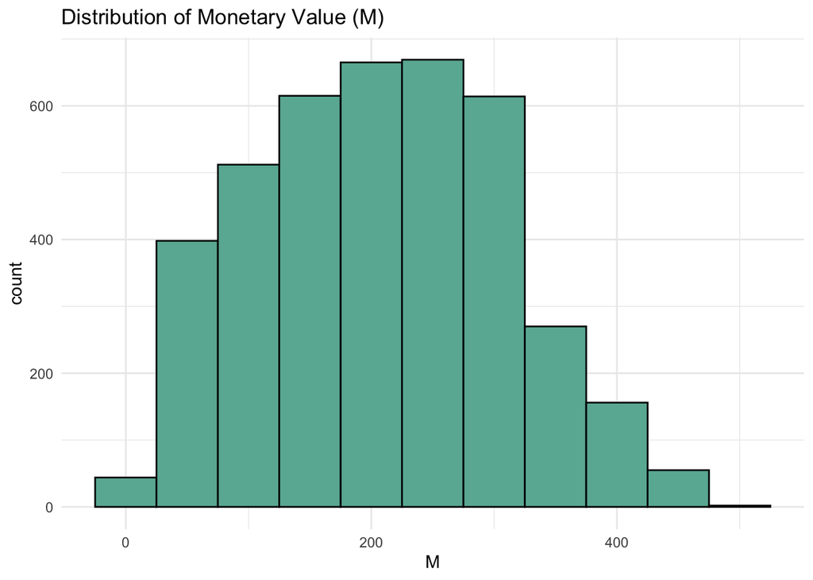

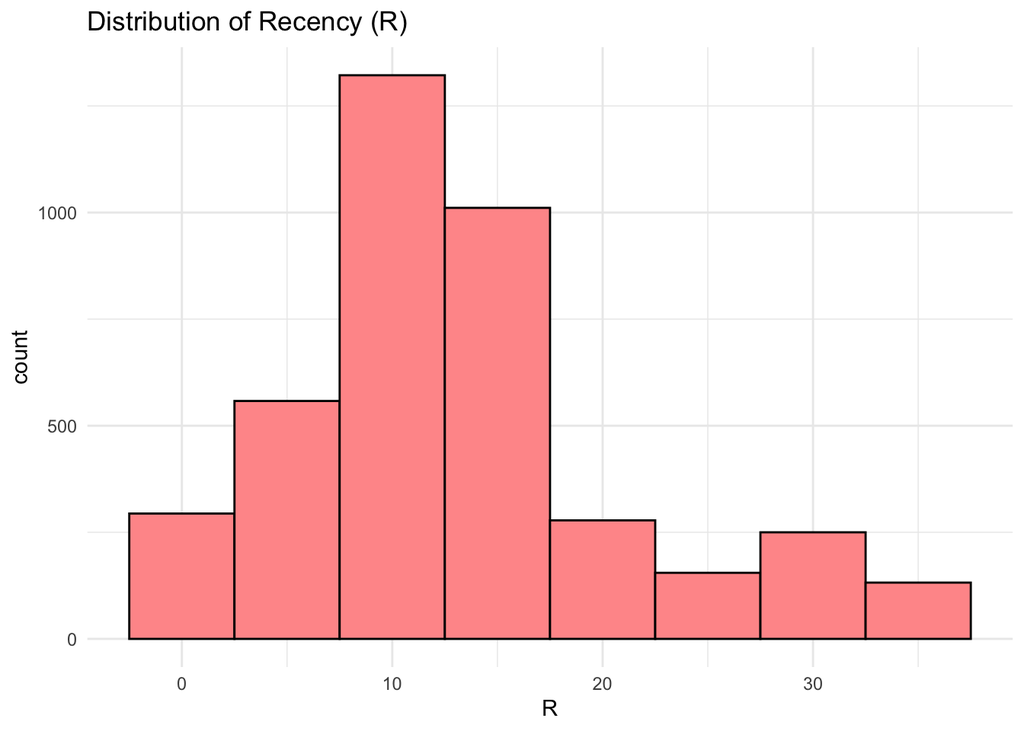

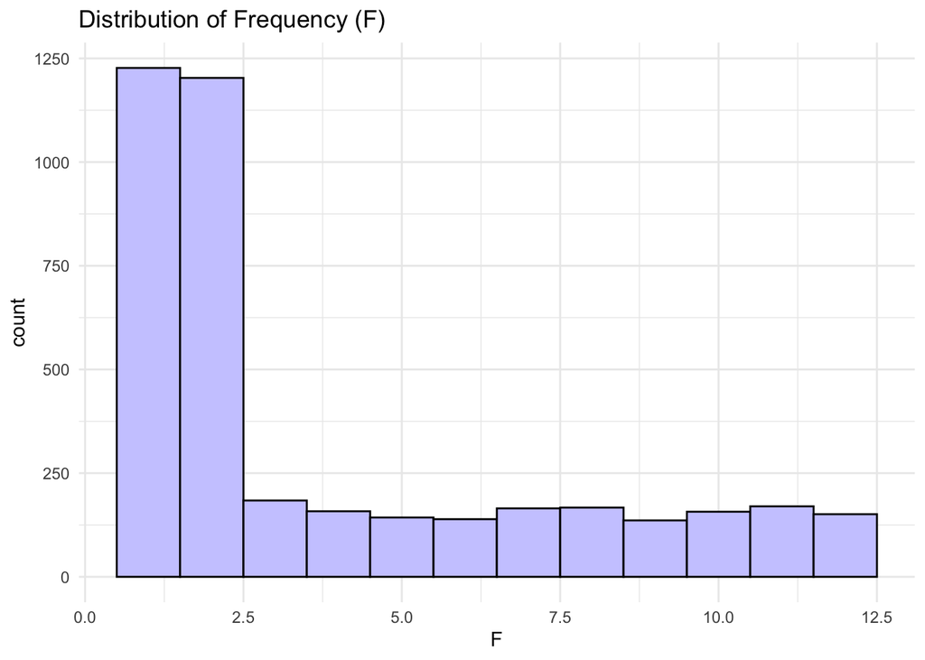

```
## [1] "Correlation among RFM variables:"
```

```
##             R          F           M
## R 1.000000000 0.00279687 0.007779124
## F 0.002796870 1.00000000 0.509034620
## M 0.007779124 0.50903462 1.000000000
```

Partition of data set into a training set (60%) and a validation set (40%).

Q1 What is the response rate for the training data customers taken as a whole? What is the response rate for each of the 4X5X3 = 60 combinations of RFM categories? Which combinations have response rate in the training data above the overall response in the training data?

```r
# Calculate the overall response rate in the training data
overall_response_rate_training <- mean(trainData$Yes_Florence)
cat("Overall response rate in training data:", overall_response_rate_training, "\n\n")
```

```
## Overall response rate in training data: 0.08708333
```

```r
# Group the training data by RFM categories and calculate the response rate for each group
response_rates_by_rfm <- trainData %>%
  group_by(Rcode, Fcode, Mcode) %>%
  summarise(ResponseRate = mean(Yes_Florence), .groups = 'drop')

# Display response rates for each RFM category combination
print("Response rates for each of the 4x5x3 = 60 combinations of RFM categories:")
```

```
## [1] "Response rates for each of the 4x5x3 = 60 combinations of RFM categories:"
```

```r
print(response_rates_by_rfm)
```

```
## # A tibble: 51 × 4
##    Rcode Fcode Mcode ResponseRate
##    <int> <int> <int>        <dbl>
##  1     1     1     1        0
##  2     1     1     2        0
##  3     1     1     3        0
##  4     1     1     4        0.25
##  5     1     1     5        0.115
##  6     1     2     2        0.5
##  7     1     2     3        0
##  8     1     2     4        0
##  9     1     2     5        0.118
## 10     1     3     2        1
## # ℹ 41 more rows
```

Note that there are only 51 combinations that are used in this dataset. The other response rates would be 0.

```r
# Identify which combinations have a response rate above the overall response rate in the training data
high_response_combinations <- response_rates_by_rfm %>%
  filter(ResponseRate > overall_response_rate_training)

# Output the overall response rate
print(paste("Overall response rate in training data:", overall_response_rate_training))
```

```
## [1] "Overall response rate in training data: 0.0870833333333333"
```

```r
# Output the response rates by RFM category
print("Response rates by RFM category:")
```

```
## [1] "Response rates by RFM category:"
```

```r
print(response_rates_by_rfm)
```

```
## # A tibble: 51 × 4
##    Rcode Fcode Mcode ResponseRate
##    <int> <int> <int>        <dbl>
##  1     1     1     1        0
##  2     1     1     2        0
##  3     1     1     3        0
##  4     1     1     4        0.25
##  5     1     1     5        0.115
##  6     1     2     2        0.5
##  7     1     2     3        0
##  8     1     2     4        0
##  9     1     2     5        0.118
## 10     1     3     2        1
## # ℹ 41 more rows
```

```r
# Output the combinations with high response rates
print("Combinations with higher response rates than overall:")
```

```
## [1] "Combinations with higher response rates than overall:"
```

```r
print(high_response_combinations)
```

```
## # A tibble: 19 × 4
##    Rcode Fcode Mcode ResponseRate
##    <int> <int> <int>        <dbl>
##  1     1     1     4        0.25
##  2     1     1     5        0.115
##  3     1     2     2        0.5
##  4     1     2     5        0.118
##  5     1     3     2        1
##  6     1     3     5        0.170
##  7     2     1     1        0.333
##  8     2     1     2        0.333
##  9     2     1     3        0.136
## 10     2     1     5        0.179
## 11     2     2     3        0.167
## 12     2     2     4        0.114
## 13     2     2     5        0.114
## 14     2     3     3        0.333
## 15     2     3     4        0.146
## 16     2     3     5        0.151
## 17     3     2     3        0.1
## 18     3     3     5        0.153
## 19     4     3     3        0.118
```

**Q2)** Suppose that we decide to send promotional mail only to the “above-average” RFM combinations identified in part 1. Compute the response rate in validation data using these combinations.

```r
# Identify "above-average" RFM combinations from the training data
above_average_combinations <- response_rates_by_rfm %>%
  filter(ResponseRate > overall_response_rate_training) %>%
  select(Rcode, Fcode, Mcode)

# Filter validation data to include only the "above-average" RFM combinations
validation_above_average <- validationData %>%
  semi_join(above_average_combinations, by = c("Rcode", "Fcode", "Mcode"))

# Calculate the response rate among the filtered validation data
above_average_response_rate <- mean(validation_above_average$Yes_Florence)
print(above_average_combinations)
```

```
## # A tibble: 19 × 3
##    Rcode Fcode Mcode
##    <int> <int> <int>
##  1     1     1     4
##  2     1     1     5
##  3     1     2     2
##  4     1     2     5
##  5     1     3     2
##  6     1     3     5
##  7     2     1     1
##  8     2     1     2
##  9     2     1     3
## 10     2     1     5
## 11     2     2     3
## 12     2     2     4
## 13     2     2     5
## 14     2     3     3
## 15     2     3     4
## 16     2     3     5
## 17     3     2     3
## 18     3     3     5
## 19     4     3     3
```

```r
# Print the response rate
print(paste("Response rate for 'above-average' RFM combinations in validation data:", above_average_response_rate))
```

```
## [1] "Response rate for 'above-average' RFM combinations in validation data: 0.103139013452915"
```

**Q3)** Rework parts 1 and 2 with three segments: Segment 1: RFM combinations that have response rates that exceed twice the overall response rate Segment 2: RFM combinations that exceed the overall response rate but do not exceed twice the overall response rate. Segment 3: RFM of the remaining RFM combinations

Draw the lift curve showing the number of customers in the validation dataset on the x-axis and cumulative number of buyers in the validation dataset on the y-axis. The lift curve consists of three points for the previous three segments.

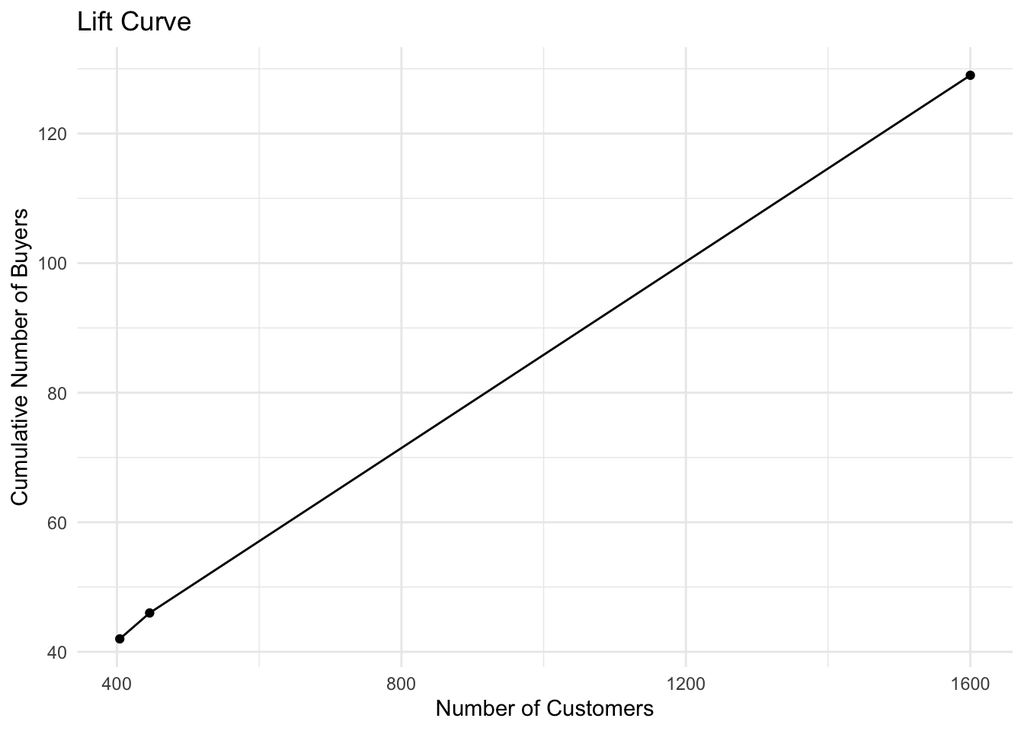

```r
# Calculate the overall response rate in the training data
overall_response_rate_training <- mean(trainData$Yes_Florence)

# Group the training data by RFM categories and calculate the response rate for each group
response_rates_by_rfm <- trainData %>%
  group_by(Rcode, Fcode, Mcode) %>%
  summarise(ResponseRate = mean(Yes_Florence), .groups = 'drop') %>%
  mutate(Segment = case_when(
    ResponseRate > 2 * overall_response_rate_training ~ "Segment 1: >2x Overall",
    ResponseRate > overall_response_rate_training ~ "Segment 2: >1x and <=2x Overall",
    TRUE ~ "Segment 3: <=1x Overall"
  ))

# Join segments with validation data
validation_segmented <- validationData %>%
  left_join(response_rates_by_rfm, by = c("Rcode", "Fcode", "Mcode"))

# Calculate the response rate for each segment in the validation data
segment_response_rates <- validation_segmented %>%
  group_by(Segment) %>%
  summarise(Customers = n(), Buyers = sum(Yes_Florence), ResponseRate = mean(Yes_Florence), .groups = 'drop') %>%
  arrange(desc(ResponseRate))

# Calculate cumulative buyers and customers
segment_response_rates <- segment_response_rates %>%
  mutate(CumulativeBuyers = cumsum(Buyers),
         CumulativeCustomers = cumsum(Customers))

# Draw the lift curve
ggplot(segment_response_rates, aes(x = CumulativeCustomers, y = CumulativeBuyers)) +
  geom_point() +
  geom_line() +
  ggtitle("Lift Curve") +
  xlab("Number of Customers") +
  ylab("Cumulative Number of Buyers") +
  theme_minimal()
```

```r
# Output the summary table for review
print(segment_response_rates)
```

```
## # A tibble: 3 × 6
##   Segment     Customers Buyers ResponseRate CumulativeBuyers CumulativeCustomers
##   <chr>           <int>  <int>        <dbl>            <int>               <int>
## 1 Segment 2:…       404     42       0.104                42                 404
## 2 Segment 1:…        42      4       0.0952               46                 446
## 3 Segment 3:…      1154     83       0.0719              129                1600
```

**Q4)** Use the k-nearest-neighbor approach to classify cases with k = 1, 2, …, 11, using Florence as the outcome variable. Based on the validation set, find the best k. Remember to normalize all five variables. Create a lift curve for the best k model, and report the expected lift for an equal number of customers from the validation dataset.

```r
set.seed(1)  # For reproducibility

# Normalize the variables
df_normalized <- as.data.frame(scale(df[, c(4,5,6,7,19)]))

# Add the outcome variable back to the dataset
df_normalized$Florence <- df$Florence


# Prepare the training and validation datasets from normalized data
trainIndex <- createDataPartition(df_normalized$Florence, p = 0.6, list = FALSE)
trainData <- df_normalized[trainIndex, ]
validationData <- df_normalized[-trainIndex, ]

# Function to perform k-NN and return accuracy
accuracy_per_k <- function(k) {
  predicted_labels <- knn(train = trainData[, -6], test = validationData[, -6], cl = trainData$Florence, k = k)
  mean(predicted_labels == validationData$Florence)
}


# Test k values from 1 to 11
k_values <- 1:11
accuracies <- sapply(k_values, accuracy_per_k)
best_k <- k_values[which.max(accuracies)]
accuracies
```

```
##  [1] 0.860000 0.913750 0.902500 0.918750 0.910000 0.918750 0.916250 0.919375
##  [9] 0.917500 0.918750 0.919375
```

```r
cat("Best k:", best_k, "with accuracy:", max(accuracies))
```

```
## Best k: 8 with accuracy: 0.919375
```

```r
# Combine k values and their corresponding accuracies into a data frame
results_df <- data.frame(
  k = k_values,
  accuracy = accuracies
)

# Print the results as a data frame
print(results_df)
```

```
##     k accuracy
## 1   1 0.860000
## 2   2 0.913750
## 3   3 0.902500
## 4   4 0.918750
## 5   5 0.910000
## 6   6 0.918750
## 7   7 0.916250
## 8   8 0.919375
## 9   9 0.917500
## 10 10 0.918750
## 11 11 0.919375
```

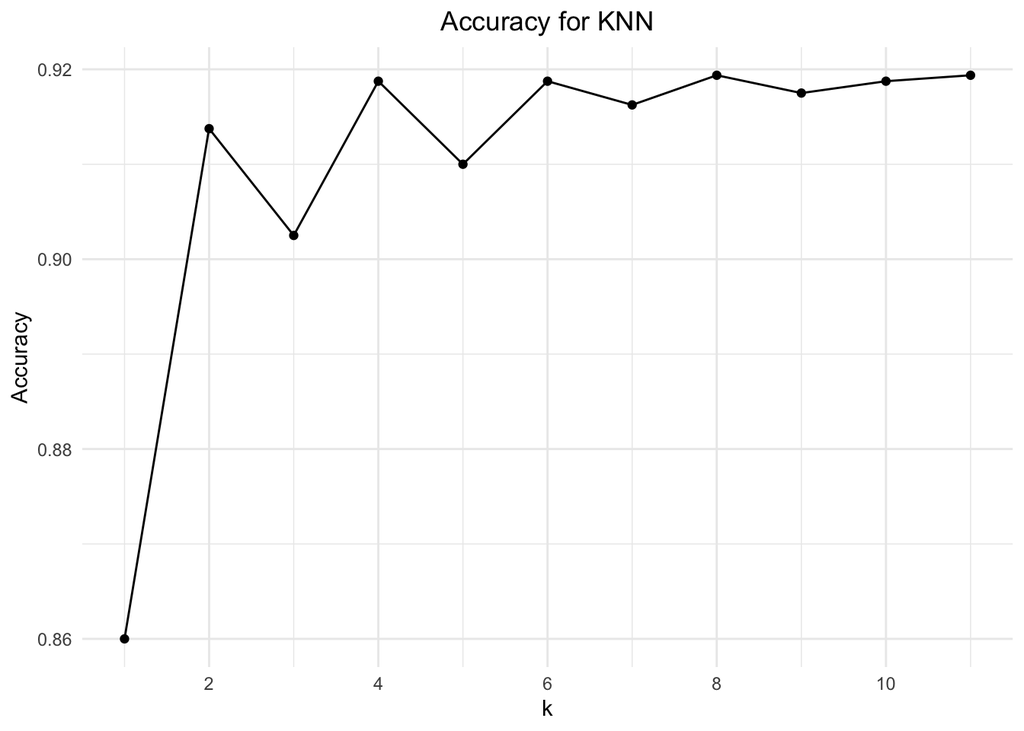

```r
# Create a data frame for plotting
accuracy_data <- data.frame(k = k_values, accuracy = accuracies)

# Plot the accuracy for different k values
ggplot(accuracy_data, aes(x = k, y = accuracy)) +
  geom_line() +  # Line to connect the points
  geom_point() +  # Points at each k value
  labs(title = "Accuracy for KNN", x = "k", y = "Accuracy") +
  theme_minimal() +  # Minimalist theme
  scale_x_continuous(breaks = seq(2, max(k_values), by = 2)) +
  theme(plot.title = element_text(hjust = 0.5))
```

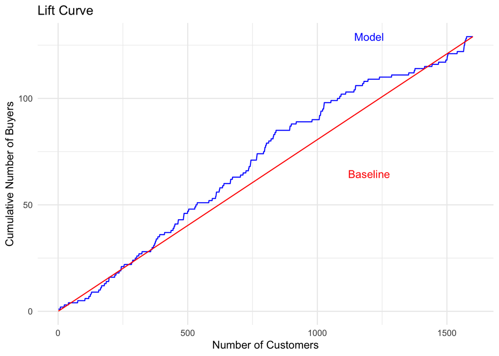

```r
# Step 1: Predict using the best k
best_k_predictions <- knn(train = trainData[, -6], test = validationData[, -6], cl = trainData$Florence, k = best_k)

# Step 2: Convert predictions to a numerical binary format for scoring
validationData$score <- as.numeric(best_k_predictions == "1")
validationData$actual <- as.numeric(validationData$Florence == "1")

# Step 3: Order data by score in descending order
validationData <- validationData[order(validationData$score, decreasing = TRUE),]

# Step 4: Calculate cumulative response
validationData$cumulative_buyers <- cumsum(validationData$actual)

# Calculate the baseline (random guessing)
total_buyers <- sum(validationData$actual)
total_customers <- nrow(validationData)
baseline <- cumsum(rep(total_buyers/total_customers, total_customers))

# Step 5: Plot the lift curve
df_lift <- data.frame(
  Customers = 1:total_customers,
  CumulativeBuyersModel = validationData$cumulative_buyers,
  Baseline = baseline
)

lift_plot <- ggplot(df_lift, aes(x = Customers)) +
  geom_line(aes(y = CumulativeBuyersModel), color = "blue") +
  geom_line(aes(y = Baseline), color = "red") +
  labs(title = "Lift Curve", x = "Number of Customers", y = "Cumulative Number of Buyers") +
  theme_minimal() +
  annotate("text", x = total_customers * 0.75, y = total_buyers, label = "Model", color = "blue") +
  annotate("text", x = total_customers * 0.75, y = total_buyers / 2, label = "Baseline", color = "red")

print(lift_plot)
```

```r
# Step 6: Calculate expected lift
expected_lift <- validationData$cumulative_buyers[total_customers] / baseline[total_customers]
cat("Expected lift for an equal number of customers:", expected_lift, "\n")
```

```
## Expected lift for an equal number of customers: 1
```

**Q5)** The k-NN prediction algorithm gives a numerical value, which is a weighted average of the values of the Florence variable for the k-nearest neighbors with weights that are inversely proportional to distance. Using the best k that you calculated above with k-NN classification, now run a model with k-NN prediction and compute a lift curve for the validation data. Use all 5 predictors and normalized data. What is the range within which a prediction will fall? How does this result compare to the output you get with the k-nearest-neighbor classification?

```r
# Define the column names of the predictors explicitly
predictor_columns <- names(trainData)[names(trainData) != "Florence"]  # Assuming 'Florence' is the column to predict

# Prepare the predictors datasets by selecting the same columns explicitly
train_predictors <- trainData[, predictor_columns]
validation_predictors <- validationData[, predictor_columns]

# Check if the number of columns matches
if (ncol(train_predictors) != ncol(validation_predictors)) {
  stop("The number of columns in the training and validation datasets do not match.")
} else {
  message("The number of columns match. Proceeding with k-NN regression.")
}
```

```
## The number of columns match. Proceeding with k-NN regression.
```

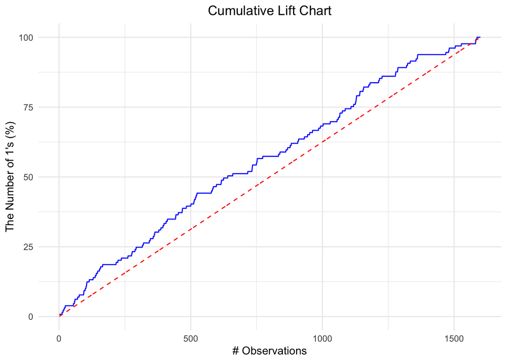

```r
# Predict using k-NN regression with automatic distance weighting
knn_predictions_weighted <- knn.reg(train = train_predictors, test = validation_predictors, y = trainData$Florence, k = best_k)

# Store the predicted values
validationData$weighted_scores <- knn_predictions_weighted$pred



# Calculate the overall response rate
overall_rate <- mean(validationData$Florence == 1)

# Cumulative Lift Chart
validationData <- validationData %>%
  arrange(desc(weighted_scores)) %>%
  mutate(
    cumulative_positives = cumsum(Florence),
    total_positives = sum(Florence),
    percentage_cumulative_positives = 100 * cumulative_positives / total_positives,
    expected_percentage = 100 * seq_along(Florence) / n()
  )

# Create the Cumulative Lift Chart with a centered title
cumulative_lift_plot <- ggplot(validationData, aes(x = seq_along(Florence))) +
  geom_line(aes(y = percentage_cumulative_positives), color = "blue") +
  geom_line(aes(y = expected_percentage), linetype = "dashed", color = "red") +
  labs(title = "Cumulative Lift Chart", x = "# Observations", y = "The Number of 1's (%)") +
  theme_minimal() +
  theme(plot.title = element_text(hjust = 0.5))  # Centering the title

print(cumulative_lift_plot)
```